# 10_Samples_to_Pull

Calen P. Ryan

21 May, 2019

Started around April 29th, 2019

–

When it comes to data, I’m a pretty visual person. Visualizing data is an important step for me towards understanding it. The benefit of realizing this has been that the act of getting my data organized enough to visualize it usually gets me 95% towards trying to do what I want.

This is especially true for the longterm dataset I work with, which made up of 35 years of data, in thousands of people, over hundreds of individual files, each of which has hundreds of variables. It can be pretty hairy, and sometimes needs to be tortured to get it to where I need it to be. It isn’t always pretty, but if I get it there, I call it a success. Don’t @ me about writing more functions! haha

I am sort of jumping in the middle here, but today I’m going to post some stuff I’m doing to parse out dates for blood samples relative to pregnancy (parturition) dates. What I ultimately want is blood samples of during pregnancy for a subset of individuals that were covered in an NSF funded study.

# For the Pregnancy Samples:

First, I read in the file I created earlier (09_Plot_Preg_Changes.Rmd), and have a look.

```r
pregord.long.clean <- read_csv(here::here("Output/Data/pregord.long.clean.csv"))
pregord.long.clean
```

```
## # A tibble: 248 x 6
##    uncchdid reprostat     sample             date       time         pregs
##       <dbl> <chr>         <chr>              <date>     <chr>        <dbl>
##  1    20007 breastfeeding term.or.draw.date  2002-11-15 pregord_2005     1
##  2    20007 breastfeeding new.preg.term.date 2011-03-05 new.preg         3
##  3    20010 breastfeeding term.or.draw.date  2003-10-14 pregord_2005     1
##  4    20010 breastfeeding new.preg.term.date 2009-12-09 new.preg         2
##  5    20036 pregnant      term.or.draw.date  2004-09-07 pregord_2005     1
##  6    20036 pregnant      new.preg.term.date 2013-05-06 new.preg         4
##  7    20042 breastfeeding term.or.draw.date  2003-10-25 pregord_2005     2
##  8    20042 breastfeeding new.preg.term.date 2014-03-15 new.preg         4
##  9    20110 pregnant      term.or.draw.date  2004-10-26 pregord_2005     1
## 10    20110 pregnant      new.preg.term.date 2012-12-11 new.preg         4
## # … with 238 more rows
```

Next I will read in the barcode information I obtained from other sources.

```r
barcode_ids <- read_csv(here::here("Data/Other/barcode_ids.csv"))
barcode_ids %>% arrange(dbs_date)
```

```
## # A tibble: 504 x 17
##    uncchdid basebrgy basewman dbs_date   shipdatepr          pregnum
##       <dbl>    <dbl>    <dbl> <date>     <dttm>                <dbl>
##  1    21907       13      431 2009-03-18 2009-10-19 00:00:00       1
##  2    21839       13      355 2009-03-19 2009-10-19 00:00:00       1
##  3    20395        3      229 2009-03-20 2009-10-19 00:00:00       1
##  4    22224       16       92 2009-03-20 2009-10-19 00:00:00       1
##  5    20156        2       39 2009-03-21 2009-10-19 00:00:00       1
##  6    20917        8       41 2009-03-24 2009-10-19 00:00:00       1
##  7    20956        8       98 2009-03-24 2009-10-19 00:00:00       1
##  8    20631        6       22 2009-03-25 2009-10-19 00:00:00       1
##  9    21100        9      135 2009-03-27 2009-10-19 00:00:00       1
## 10    21090        9      125 2009-03-28 2009-10-19 00:00:00       1
## # … with 494 more rows, and 11 more variables: specimen_id <dbl>,
## #   tech_id <chr>, date_received <dttm>, basehhld <dbl>,
## #   number_spots_80_percent <dbl>, comment_codes <dbl>, punches <dbl>,
## #   original_bag_name <chr>, bag_number <dbl>, bundle_number <dbl>,
## #   card_number <dbl>
```

I will use intersect to see if I have any names that overlap.

```r
intersect(names(barcode_ids), names(pregord.long.clean))
```

```
## [1] "uncchdid"
```

I have date in both, but one is for DBS and one is for pregnancy (parturition date) presumably.

First of all, I don’t want ALL the pregnancies - many of these are from 2005, and I already have processed those samples.

```r
pregord.long.clean %>% filter(time == "new.preg")
```

```
## # A tibble: 124 x 6
##    uncchdid reprostat     sample             date       time     pregs
##       <dbl> <chr>         <chr>              <date>     <chr>    <dbl>
##  1    20007 breastfeeding new.preg.term.date 2011-03-05 new.preg     3
##  2    20010 breastfeeding new.preg.term.date 2009-12-09 new.preg     2
##  3    20036 pregnant      new.preg.term.date 2013-05-06 new.preg     4
##  4    20042 breastfeeding new.preg.term.date 2014-03-15 new.preg     4
##  5    20110 pregnant      new.preg.term.date 2012-12-11 new.preg     4
##  6    20144 breastfeeding new.preg.term.date 2013-07-15 new.preg     5
##  7    20156 pregnant      new.preg.term.date 2009-05-28 new.preg     4
##  8    20283 nulliparous   new.preg.term.date 2013-01-11 new.preg     2
##  9    20313 breastfeeding new.preg.term.date 2010-05-19 new.preg     3
## 10    20319 pregnant      new.preg.term.date 2010-09-07 new.preg     2
## # … with 114 more rows
```

I figured out the criteria I want to be able to look at my data:

- Date the x-axis
- Each individual (uncchdid) on the Y axis.
- Colored by sample kind:
  - Dried Blood Spot (DBS) date as one color (maybe red?)
  - Pregnancy date as another color (maybe blue?)

I’ll filter a bit, rename some variables, and merge the two datasets vertically (tidy), and select the columns I want. If you want to see the process, click the `code` button.

```r
# Columns = uncchdid, date (preg or dbs), pregnumb (or pregs),

foo.long.clean <-pregord.long.clean %>% # bind rows together (all of this below)
  filter(time == "new.preg") %>% # only NSF pregnancies
  rename(preg.no = pregs) %>%    # rename pregnancies
  mutate(preg.no.type = "total_pregs") %>%
  mutate(date.sample.type = "Parturition") %>%
  select(uncchdid, date.sample.type, date, preg.no.type, preg.no) # select columns I want.


foo.barcode <-barcode_ids %>%
  rename(preg.no = pregnum) %>% # rename
  rename(date = dbs_date) %>%
  mutate(preg.no.type = "nsf_pregs") %>% # new column for rbind (so I know where it came from)
  mutate(date.sample.type = "Pregnancy_DBS") %>%  # new column for rbind (so I know where it came from)
  filter(uncchdid %in% pregord.long.clean$uncchdid) %>%  # only pull DBS columns in NSF
  select(uncchdid, date.sample.type, date, preg.no.type, preg.no) # select
```

Use for graphics below.

```r
pregs_dbs_dates <- bind_rows(foo.long.clean, foo.barcode)

pregs_dbs_dates %>% arrange(uncchdid)
```

```
## # A tibble: 292 x 5
##    uncchdid date.sample.type date       preg.no.type preg.no
##       <dbl> <chr>            <date>     <chr>          <dbl>
##  1    20007 Parturition      2011-03-05 total_pregs        3
##  2    20007 Pregnancy_DBS    2011-01-28 nsf_pregs          1
##  3    20010 Parturition      2009-12-09 total_pregs        2
##  4    20010 Pregnancy_DBS    2009-09-15 nsf_pregs          1
##  5    20036 Parturition      2013-05-06 total_pregs        4
##  6    20036 Pregnancy_DBS    2010-01-08 nsf_pregs          1
##  7    20036 Pregnancy_DBS    2013-02-27 nsf_pregs          2
##  8    20042 Parturition      2014-03-15 total_pregs        4
##  9    20042 Pregnancy_DBS    2014-01-13 nsf_pregs          1
## 10    20110 Parturition      2012-12-11 total_pregs        4
## # … with 282 more rows
```

First attempt at the plot.

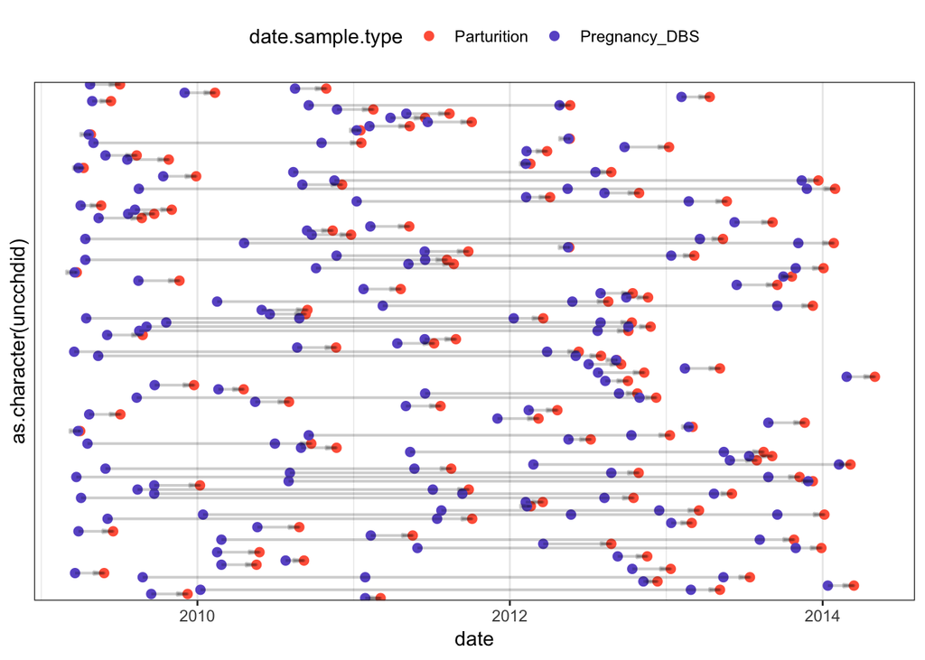

```r
ggplot(pregs_dbs_dates, aes(x = date, y = as.character(uncchdid))) +
  geom_point(aes(color = date.sample.type), pch = 19, size = 2)+
  geom_line(aes(group = uncchdid), size=0.7, alpha = 0.2, arrow = arrow(type = "closed", angle = 8, length = unit(2, "mm")))+ # add the arrows - yes I fine tuned this.
  scale_color_manual(values = c("tomato", "slateblue"))+ # nice colors
  theme_bw()+ # clean format
  theme(legend.position = "top")+ # more clean looks
  scale_y_discrete(breaks = NULL) # more clean looks
```

It’s kind of hard to look at with dates all noisy like this. Lets arrange by date. I’ll do this in the ggplot function

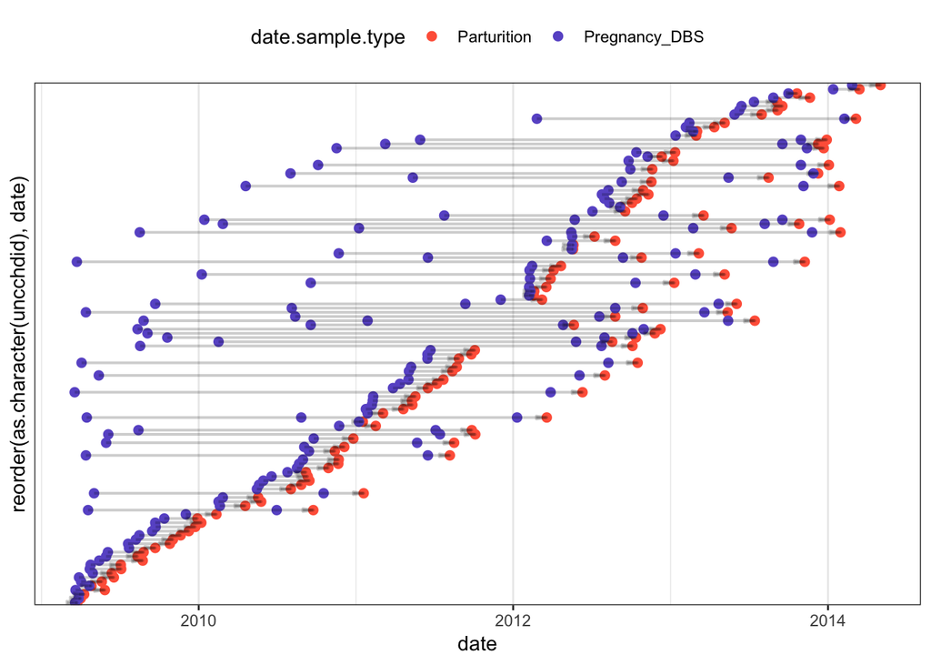

```r
ggplot(pregs_dbs_dates, aes(x = date, y = reorder(as.character(uncchdid), date))) + # This arranges by date. Not perfect but better
  geom_point(aes(color = date.sample.type), pch = 19, size = 2)+
  geom_line(aes(group = uncchdid), size=0.7, alpha = 0.2, arrow = arrow(type = "closed", angle = 8, length = unit(2, "mm")))+ # add the arrows - yes I fine tuned this.
  scale_color_manual(values = c("tomato", "slateblue"))+ # nice colors
  theme_bw()+ # clean format
  theme(legend.position = "top")+ # more clean looks
  scale_y_discrete(breaks = NULL) # more clean looks
```

Way better. But from this I can see that I have multiple blood samples for some women, but am only interested in their last (latest, most recent pregnancy).

I might want to facet by Year - that could show me some other interesting patterns.

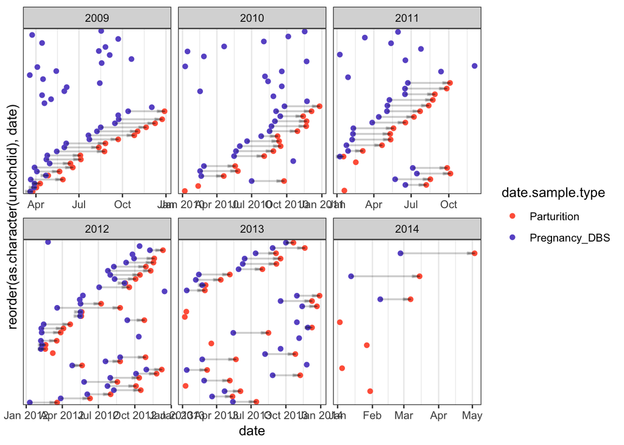

```r
pregs_dbs_dates$Year <- format(pregs_dbs_dates$date, "%Y")

ggplot(pregs_dbs_dates, aes(x = date, y = reorder(as.character(uncchdid), date))) +
    geom_point(aes(color = date.sample.type), pch = 19) + geom_line(aes(group = uncchdid),
    size = 0.7, alpha = 0.2, arrow = arrow(type = "closed", angle = 8, length = unit(2,
        "mm"))) + scale_color_manual(values = c("tomato", "slateblue")) + theme_bw() +
    facet_wrap(~Year, scales = c("free")) + scale_y_discrete(breaks = NULL)
```

That helps a bit, but still not great.

What I will do is group by ID, create a ‘count’ of blood sample based on date, and then use that to partition the data, then ungroup.

```r
pregs_dbs_dates <- pregs_dbs_dates %>% group_by(uncchdid) %>% mutate(N = n()) %>%
    ungroup()

pregs_dbs_dates
```

```
## # A tibble: 292 x 7
##    uncchdid date.sample.type date       preg.no.type preg.no Year      N
##       <dbl> <chr>            <date>     <chr>          <dbl> <chr> <int>
##  1    20007 Parturition      2011-03-05 total_pregs        3 2011      2
##  2    20010 Parturition      2009-12-09 total_pregs        2 2009      2
##  3    20036 Parturition      2013-05-06 total_pregs        4 2013      3
##  4    20042 Parturition      2014-03-15 total_pregs        4 2014      2
##  5    20110 Parturition      2012-12-11 total_pregs        4 2012      2
##  6    20144 Parturition      2013-07-15 total_pregs        5 2013      4
##  7    20156 Parturition      2009-05-28 total_pregs        4 2009      2
##  8    20283 Parturition      2013-01-11 total_pregs        2 2013      2
##  9    20313 Parturition      2010-05-19 total_pregs        3 2010      2
## 10    20319 Parturition      2010-09-07 total_pregs        2 2010      2
## # … with 282 more rows
```

Ok, that looks like what I want.

Let’s try to replot, but this time I’ll facet by the count. This should clean things up.

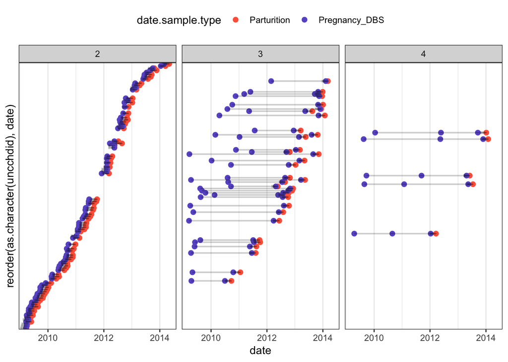

```r
pregs_dbs_dates %>% ggplot(., aes(x = date, y = reorder(as.character(uncchdid),
    date))) + geom_point(aes(color = date.sample.type), size = 2) + scale_color_manual(values = c("tomato",
    "slateblue")) + theme_bw() + theme(legend.position = "top") + geom_line(aes(group = uncchdid),
    size = 0.7, alpha = 0.2, arrow = arrow(type = "closed", angle = 8, length = unit(2,
        "mm"))) + scale_y_discrete(breaks = NULL) + facet_wrap(~factor(N))
```

Way better.

The reason I have all these “extra” DBS samples is because I calculated the last pregnancy in the NSF study, but we have blood samples for sometimes several of them. This is fine. I can easily filter to the “highest” (latest) dates.

```r
pregs_dbs_dates_reduced <- pregs_dbs_dates %>% group_by(uncchdid, date.sample.type) %>%
    mutate(max.date = max(date)) %>% arrange(uncchdid) %>% top_n(1, date) %>%
    ungroup()


pregs_dbs_dates_reduced
```

```
## # A tibble: 248 x 8
##    uncchdid date.sample.type date       preg.no.type preg.no Year      N
##       <dbl> <chr>            <date>     <chr>          <dbl> <chr> <int>
##  1    20007 Parturition      2011-03-05 total_pregs        3 2011      2
##  2    20007 Pregnancy_DBS    2011-01-28 nsf_pregs          1 2011      2
##  3    20010 Parturition      2009-12-09 total_pregs        2 2009      2
##  4    20010 Pregnancy_DBS    2009-09-15 nsf_pregs          1 2009      2
##  5    20036 Parturition      2013-05-06 total_pregs        4 2013      3
##  6    20036 Pregnancy_DBS    2013-02-27 nsf_pregs          2 2013      3
##  7    20042 Parturition      2014-03-15 total_pregs        4 2014      2
##  8    20042 Pregnancy_DBS    2014-01-13 nsf_pregs          1 2014      2
##  9    20110 Parturition      2012-12-11 total_pregs        4 2012      2
## 10    20110 Pregnancy_DBS    2012-11-08 nsf_pregs          1 2012      2
## # … with 238 more rows, and 1 more variable: max.date <date>
```

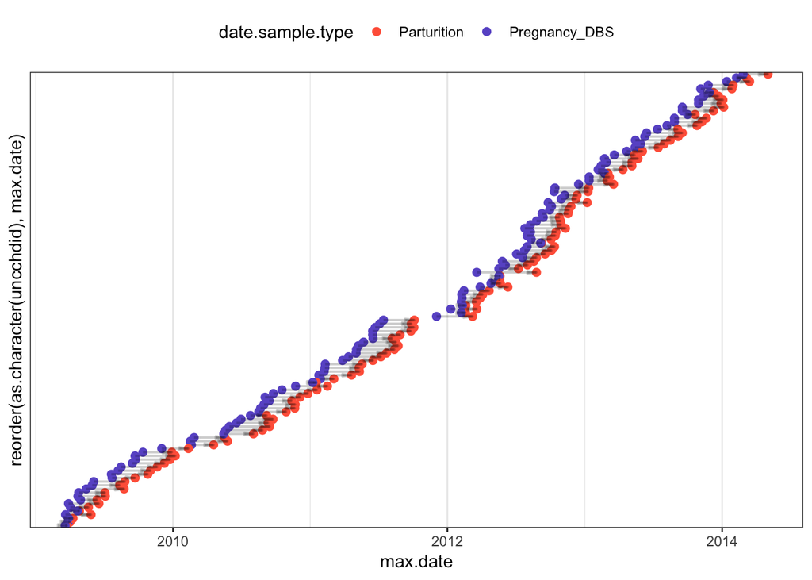

```r
pregs_dbs_dates_reduced %>% ggplot(., aes(x = max.date, y = reorder(as.character(uncchdid),
    max.date))) + geom_point(aes(color = date.sample.type), size = 2) + scale_color_manual(values = c("tomato",
    "slateblue")) + theme_bw() + theme(legend.position = "top") + geom_line(aes(group = uncchdid),
    size = 0.7, alpha = 0.2, arrow = arrow(type = "closed", angle = 8, length = unit(2,
        "mm"))) + scale_y_discrete(breaks = NULL)
```

Oooooooooh, pretty nice!

Now I’ll just clean up the labels, rearrange lowest to highest, add back the IDs, make the legend look nicer, and make it long enough to see the ylabs properly.

[figure not shown]

```r
pregs_dbs_dates_reduced %>% filter(N < 3) %>% ggplot(., aes(x = max.date, y = reorder(as.character(uncchdid),
    desc(max.date)))) + geom_point(aes(color = date.sample.type), size = 2.5) +
    scale_color_manual(name = "Sample Type", values = c("firebrick1", "royalblue1"),
        labels = c("Dried Blood Spot", "Parturition")) + theme_bw() + theme(legend.position = "top") +
    geom_line(aes(group = uncchdid), color = "palegreen3", size = 0.7, alpha = 0.5,
        arrow = arrow(type = "closed", angle = 20, length = unit(2, "mm"))) +
    labs(x = "Date of Sample", y = "uncchdid")
```

[figure not shown]

```r
pregs_dbs_dates_reduced %>% filter(N > 2) %>% ggplot(., aes(x = max.date, y = reorder(as.character(uncchdid),
    desc(max.date)))) + geom_point(aes(color = date.sample.type), size = 2.5) +
    scale_color_manual(name = "Legend", values = c("firebrick1", "royalblue1"),
        labels = c("DBS Date", "Parturition Date")) + theme_bw() + theme(legend.position = "top") +
    geom_line(aes(group = uncchdid), color = "palegreen3", size = 0.7, alpha = 0.5,
        arrow = arrow(type = "closed", angle = 20, length = unit(2, "mm"))) +
    labs(x = "Date of Sample", y = "uncchdid")
```

```r
# Optional - to look at repeat categories. Note N = number of obs, so
# including pregnancy date = N = 2 for a single DBS.
```

This is exactly what I wanted. But now I need to do the same thing (from the top) with the Birth/Screen Samples.

# For the birth samples…

```r
screen_info <-read_csv(here("Data/Other/screen_anthro_data_for_birth_DBSinfo.csv"))
names(screen_info)
```

```
##  [1] "uncchdid"              "basewman"
##  [3] "basebrgy_birth_screen" "basehhno_birth_screen"
##  [5] "basebrgy_anthrop"      "basehhno_anthrop"
##  [7] "icscreen.date"         "icanthro.date"
##  [9] "time.elapsed"          "noblood"
## [11] "bspotcard"             "placenflag"
## [13] "placenta"              "new.preg.term.date"
```

```r
foo.screen.info <-screen_info %>%
  select(-basebrgy_birth_screen, -basehhno_birth_screen, -icscreen.date) %>%
  rename(basebrgy = "basebrgy_anthrop", basehhld = "basehhno_anthrop", date = icanthro.date) %>%
  mutate(date.sample.type = "Birth") %>%
  filter(uncchdid %in% pregord.long.clean$uncchdid) %>%  # only pull DBS columns in NSF
  select(uncchdid, date.sample.type, date) # select
```

```r
pregs_birth_dbs_dates <- bind_rows(foo.long.clean, foo.barcode, foo.screen.info)

pregs_birth_dbs_dates$Year <- format(pregs_birth_dbs_dates$date, "%Y")


pregs_birth_dbs_dates_reduced <- pregs_birth_dbs_dates %>% group_by(uncchdid,
    date.sample.type) %>% mutate(max.date = max(date)) %>% arrange(uncchdid) %>%
    top_n(1, date) %>% ungroup()


pregs_birth_dbs_dates_reduced %<>% as_factor(date.sample.type) %>% mutate(date.sample.type = fct_relevel(date.sample.type,
    "Pregnancy_DBS", "Birth", "Parturition"))

pregs_birth_dbs_dates %>% arrange(uncchdid)
```

```
## # A tibble: 460 x 6
##    uncchdid date.sample.type date       preg.no.type preg.no Year
##       <dbl> <chr>            <date>     <chr>          <dbl> <chr>
##  1    20007 Parturition      2011-03-05 total_pregs        3 2011
##  2    20007 Pregnancy_DBS    2011-01-28 nsf_pregs          1 2011
##  3    20007 Birth            2011-03-08 <NA>              NA 2011
##  4    20010 Parturition      2009-12-09 total_pregs        2 2009
##  5    20010 Pregnancy_DBS    2009-09-15 nsf_pregs          1 2009
##  6    20010 Birth            2009-12-11 <NA>              NA 2009
##  7    20036 Parturition      2013-05-06 total_pregs        4 2013
##  8    20036 Pregnancy_DBS    2010-01-08 nsf_pregs          1 2010
##  9    20036 Pregnancy_DBS    2013-02-27 nsf_pregs          2 2013
## 10    20036 Birth            2010-03-02 <NA>              NA 2010
## # … with 450 more rows
```

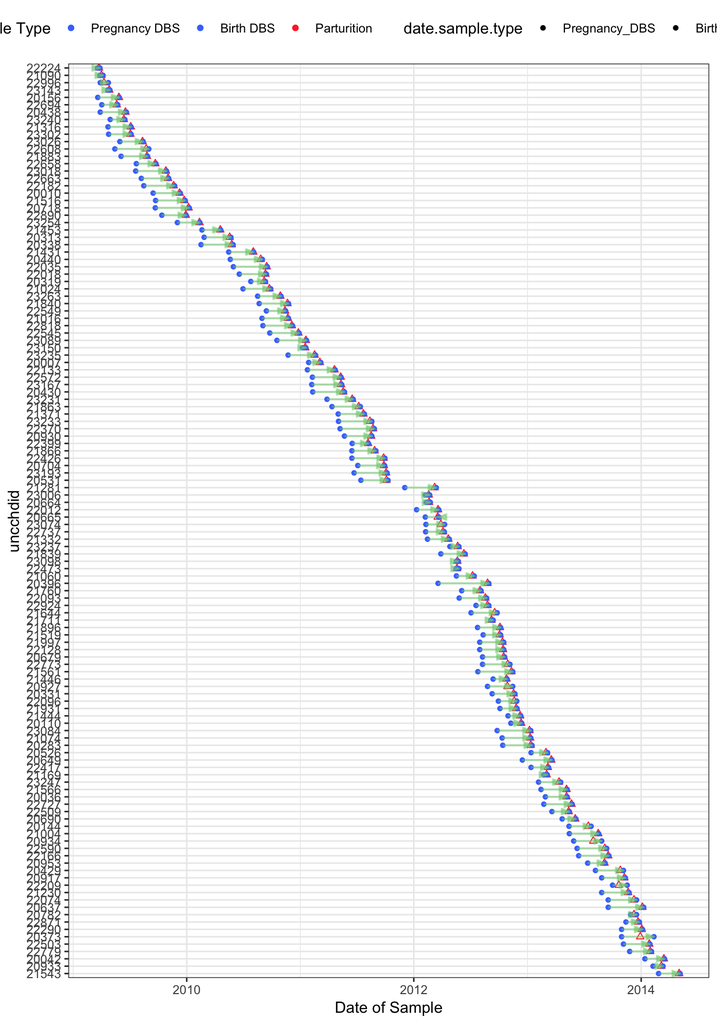

```r
pregs_birth_dbs_dates_reduced %>% ggplot(., aes(x = max.date, y = reorder(as.character(uncchdid),
    desc(max.date)))) + geom_point(aes(color = date.sample.type, shape = date.sample.type)) +
    scale_color_manual(name = "Sample Type", values = c("royalblue1", "royalblue1",
        "firebrick1"), labels = c("Pregnancy DBS", "Birth DBS", "Parturition")) +
    # scale_alpha_manual(values = c(0.8, 0.7, 0.7))+
scale_shape_manual(values = c(16, 16, 2)) + # scale_size_manual(values = c(2, 4, 2))+
theme_bw() + theme(legend.position = "top") + geom_line(aes(group = uncchdid),
    color = "palegreen3", size = 0.7, alpha = 0.5, arrow = arrow(type = "closed",
        angle = 20, length = unit(2, "mm"))) + labs(x = "Date of Sample", y = "uncchdid")  # +
```

```r
# facet_wrap(~Year, scales = c('free'))+ scale_y_discrete(breaks = NULL)
```

OK that’s good enough. This isn’t the format I want but the data is all there and looks accurate.

Now recreate the file but include the variables I need for merging with ship_info etc.

Two files.

- One for Pregnancy
- One for Birth

Pregancy uses the preg.ord.clean, Birth uses the screen_info file.

shipment date, basebrgy, basewman,

# Birth DBS and screen info

```r
core_pregord <-pregord.long.clean %>% # bind rows together (all of this below)
  filter(time == "new.preg") %>% # only NSF pregnancies
  rename(preg.no = pregs) %>%    # rename pregnancies
  mutate(preg.no.type = "total_pregs") %>%
  mutate(date.sample.type = "Parturition") %>%
  rename(total.preg.no = preg.no, parturition.date = date) %>%
  select(uncchdid, parturition.date, total.preg.no)  # select columns I want.
```

```r
core_screen_info <- screen_info %>% select(-basebrgy_birth_screen, -basehhno_birth_screen,
    -icscreen.date) %>% rename(basebrgy = basebrgy_anthrop, basehhld = basehhno_anthrop,
    birth_dbs_date = icanthro.date, parturition.date = new.preg.term.date) %>%
    filter(uncchdid %in% pregord.long.clean$uncchdid)  # only pull DBS columns in NSF



left_join(core_pregord, core_screen_info, by = c("uncchdid", "parturition.date")) %>%
    group_by(uncchdid) %>% filter(n() > 1)
```

```
## # A tibble: 2 x 12
## # Groups:   uncchdid [1]
##   uncchdid parturition.date total.preg.no basewman basebrgy basehhld
##      <dbl> <date>                   <dbl>    <dbl>    <dbl>    <dbl>
## 1    20665 2012-03-18                   1       65        6       65
## 2    20665 2012-03-18                   1       65        6       65
## # … with 6 more variables: birth_dbs_date <date>, time.elapsed <dbl>,
## #   noblood <chr>, bspotcard <chr>, placenflag <chr>, placenta <chr>
```

```r
# Why do I have one individual with >1?
core_pregord %>% filter(uncchdid == "20665")
```

```
## # A tibble: 1 x 3
##   uncchdid parturition.date total.preg.no
##      <dbl> <date>                   <dbl>
## 1    20665 2012-03-18                   1
```

```r
core_screen_info %>% filter(uncchdid == "20665")
```

```
## # A tibble: 2 x 11
##   uncchdid basewman basebrgy basehhld birth_dbs_date time.elapsed noblood
##      <dbl>    <dbl>    <dbl>    <dbl> <date>                <dbl> <chr>
## 1    20665       65        6       65 2012-03-21                3 <NA>
## 2    20665       65        6       65 2012-03-21                3 <NA>
## # … with 4 more variables: bspotcard <chr>, placenflag <chr>,
## #   placenta <chr>, parturition.date <date>
```

```r
screen_info %>% filter(uncchdid == "20665")
```

```
## # A tibble: 2 x 14
##   uncchdid basewman basebrgy_birth_… basehhno_birth_… basebrgy_anthrop
##      <dbl>    <dbl>            <dbl>            <dbl>            <dbl>
## 1    20665       65                6               65                6
## 2    20665       65                6               65                6
## # … with 9 more variables: basehhno_anthrop <dbl>, icscreen.date <date>,
## #   icanthro.date <date>, time.elapsed <dbl>, noblood <chr>,
## #   bspotcard <chr>, placenflag <chr>, placenta <chr>,
## #   new.preg.term.date <date>
```

```r
# No apparent reason - exact duplicate


core_birth_dbs <- left_join(core_pregord, core_screen_info, by = c("uncchdid",
    "parturition.date")) %>% unique()  # Remove the duplicate
```

# Pregnancy DBS and screen info

```r
core_barcode_info <-barcode_ids %>%
  rename(nsf_pregnum = pregnum) %>% # rename
  rename(pregnancy_dbs_date = dbs_date) %>%
  filter(uncchdid %in% pregord.long.clean$uncchdid) %>%  # only pull DBS columns in NSF
  group_by(uncchdid) %>%
  mutate(max.date = max(pregnancy_dbs_date)) %>%
  arrange(uncchdid) %>%
  top_n(1, pregnancy_dbs_date) %>%
  ungroup()

core_barcode_info
```

```
## # A tibble: 124 x 18
##    uncchdid basebrgy basewman pregnancy_dbs_d… shipdatepr
##       <dbl>    <dbl>    <dbl> <date>           <dttm>
##  1    20007        1       27 2011-01-28       2011-06-14 00:00:00
##  2    20010        1       33 2009-09-15       2009-10-19 00:00:00
##  3    20036        1       63 2013-02-27       2013-04-23 00:00:00
##  4    20042        1       72 2014-01-13       2014-04-01 00:00:00
##  5    20110        1      153 2012-11-08       2013-04-23 00:00:00
##  6    20144        2       22 2013-05-14       2013-10-21 00:00:00
##  7    20156        2       39 2009-03-21       2009-10-19 00:00:00
##  8    20283        3       87 2012-10-13       2012-11-13 00:00:00
##  9    20313        3      142 2010-02-26       2010-06-15 00:00:00
## 10    20319        3      148 2010-07-26       2010-12-13 00:00:00
## # … with 114 more rows, and 13 more variables: nsf_pregnum <dbl>,
## #   specimen_id <dbl>, tech_id <chr>, date_received <dttm>,
## #   basehhld <dbl>, number_spots_80_percent <dbl>, comment_codes <dbl>,
## #   punches <dbl>, original_bag_name <chr>, bag_number <dbl>,
## #   bundle_number <dbl>, card_number <dbl>, max.date <date>
```

```r
core_pregnancy_dbs <- left_join(core_pregord, core_barcode_info, by = c("uncchdid"))

core_pregnancy_dbs
```

```
## # A tibble: 124 x 20
##    uncchdid parturition.date total.preg.no basebrgy basewman
##       <dbl> <date>                   <dbl>    <dbl>    <dbl>
##  1    20007 2011-03-05                   3        1       27
##  2    20010 2009-12-09                   2        1       33
##  3    20036 2013-05-06                   4        1       63
##  4    20042 2014-03-15                   4        1       72
##  5    20110 2012-12-11                   4        1      153
##  6    20144 2013-07-15                   5        2       22
##  7    20156 2009-05-28                   4        2       39
##  8    20283 2013-01-11                   2        3       87
##  9    20313 2010-05-19                   3        3      142
## 10    20319 2010-09-07                   2        3      148
## # … with 114 more rows, and 15 more variables: pregnancy_dbs_date <date>,
## #   shipdatepr <dttm>, nsf_pregnum <dbl>, specimen_id <dbl>,
## #   tech_id <chr>, date_received <dttm>, basehhld <dbl>,
## #   number_spots_80_percent <dbl>, comment_codes <dbl>, punches <dbl>,
## #   original_bag_name <chr>, bag_number <dbl>, bundle_number <dbl>,
## #   card_number <dbl>, max.date <date>
```

## Shipping and Packaging Info

```r
# These methods based on code described here:
# https://rpubs.com/tf_peterson/readxl_import
excel_data <-here("Data/Other/DBS_2nd_to_6th_ship_cleaned_CPR.xls")

sheet_names <-excel_sheets(path = excel_data)

list_all <- lapply(sheet_names, function(x) read_excel(path = excel_data, sheet = x))

ship_info <-plyr::rbind.fill(list_all)


# Rename basehhno to basehhld (as per other documents)
ship_info <-ship_info %>%
  rename(basehhld = basehhno) %>%
  rename(shipdatepr = Date) %>% #rename date to shipdatepr
  sjlabelled::as_factor(Sample_Type) %>%
  as_character(uncchdid, basebrgy, basewman, basehhld) %>%
  select(-uncchdid)

str(ship_info)
```

```
## Classes 'tbl_df', 'tbl' and 'data.frame':    381 obs. of  6 variables:
##  $ Sample_Type: Factor w/ 5 levels "3rd_Pregnancy",..: 3 3 3 3 3 3 3 3 3 3 ...
##  $ Shipment   : num  2 2 2 2 2 2 2 2 2 2 ...
##  $ shipdatepr : POSIXct, format: "2010-02-01" "2010-02-01" ...
##  $ basebrgy   : chr  "27" "13" "27" "8" ...
##  $ basehhld   : chr  "63" "219" "56" "24" ...
##  $ basewman   : chr  "63" "219" "56" "24" ...
```

```r
ship_core_pregnancy_dbs <- left_join(core_pregnancy_dbs %>% as_character(basebrgy,
    basewman, basehhld), ship_info %>% filter(Sample_Type == "Pregnancy" | Sample_Type ==
    "Repeat_Preg" | Sample_Type == "3rd_Pregnancy") %>% as_character(basebrgy,
    basewman, basehhld), by = c("basebrgy", "basewman", "basehhld", "shipdatepr"))




ship_core_birth_dbs <- left_join(core_birth_dbs %>% as_character(basebrgy, basewman,
    basehhld), ship_info %>% filter(Sample_Type == "Birth" | Sample_Type ==
    "Repeat_Birth") %>% as_character(basebrgy, basewman, basehhld), by = c("basebrgy",
    "basewman", "basehhld"))


# Note that I have a duplicate for 20144

ship_core_birth_dbs %>% group_by(uncchdid) %>% filter(n() > 1) %>% ungroup()
```

```
## # A tibble: 2 x 15
##   uncchdid parturition.date total.preg.no basewman basebrgy basehhld
##      <dbl> <date>                   <dbl> <chr>    <chr>    <chr>
## 1    20144 2013-07-15                   5 22       2        22
## 2    20144 2013-07-15                   5 22       2        22
## # … with 9 more variables: birth_dbs_date <date>, time.elapsed <dbl>,
## #   noblood <chr>, bspotcard <chr>, placenflag <chr>, placenta <chr>,
## #   Sample_Type <fct>, Shipment <dbl>, shipdatepr <dttm>
```

```r
# The dates are ambiguous.
```

```r
# Spread and stack I don't necessarily want to join horizontally. What is my
# tidy data?  I need

# uncchdid, basewman, basebrgy shipdatepr date: date_type: - parturtion -
# pregnancy_dbs_date time elapsed


ship_core_pregnancy_dbs %>% mutate(time.elapsed = days(pregnancy_dbs_date -
    parturition.date)) %>% select(uncchdid, basewman, basebrgy, shipdatepr,
    time.elapsed, parturition.date, pregnancy_dbs_date) %>% gather(key = "date.type",
    "date", 6:7) %>% arrange(uncchdid)
```

```
## # A tibble: 248 x 7
##    uncchdid basewman basebrgy shipdatepr          time.elapsed  date.type
##       <dbl> <chr>    <chr>    <dttm>              <S4: Period>  <chr>
##  1    20007 27       1        2011-06-14 00:00:00 -36d 0H 0M 0S parturit…
##  2    20007 27       1        2011-06-14 00:00:00 0S            pregnanc…
##  3    20010 33       1        2009-10-19 00:00:00 -85d 0H 0M 0S parturit…
##  4    20010 33       1        2009-10-19 00:00:00 0S            pregnanc…
##  5    20036 63       1        2013-04-23 00:00:00 -68d 0H 0M 0S parturit…
##  6    20036 63       1        2013-04-23 00:00:00 0S            pregnanc…
##  7    20042 72       1        2014-04-01 00:00:00 -61d 0H 0M 0S parturit…
##  8    20042 72       1        2014-04-01 00:00:00 0S            pregnanc…
##  9    20110 153      1        2013-04-23 00:00:00 -33d 0H 0M 0S parturit…
## 10    20110 153      1        2013-04-23 00:00:00 0S            pregnanc…
## # … with 238 more rows, and 1 more variable: date <date>
```

```r
ship_core_birth_dbs %>% select(uncchdid, basewman, basebrgy, shipdatepr, time.elapsed,
    parturition.date, birth_dbs_date) %>% mutate(time.elapsed = days(time.elapsed)) %>%
    gather(key = "date.type", "date", 6:7) %>% arrange(uncchdid)
```

```
## # A tibble: 250 x 7
##    uncchdid basewman basebrgy shipdatepr          time.elapsed date.type
##       <dbl> <chr>    <chr>    <dttm>              <S4: Period> <chr>
##  1    20007 27       1        2011-06-14 00:00:00 3d 0H 0M 0S  parturit…
##  2    20007 27       1        2011-06-14 00:00:00 0S           birth_db…
##  3    20010 33       1        2010-02-01 00:00:00 2d 0H 0M 0S  parturit…
##  4    20010 33       1        2010-02-01 00:00:00 0S           birth_db…
##  5    20036 63       1        2010-06-15 00:00:00 2d 0H 0M 0S  parturit…
##  6    20036 63       1        2010-06-15 00:00:00 0S           birth_db…
##  7    20042 72       1        NA                  2d 0H 0M 0S  parturit…
##  8    20042 72       1        NA                  0S           birth_db…
##  9    20110 153      1        NA                  2d 0H 0M 0S  parturit…
## 10    20110 153      1        NA                  0S           birth_db…
## # … with 240 more rows, and 1 more variable: date <date>
```

```r
ship_core_preg_birth <- bind_rows(ship_core_pregnancy_dbs %>% mutate(time.elapsed = as.integer(pregnancy_dbs_date -
    parturition.date)) %>% select(uncchdid, basewman, basebrgy, shipdatepr,
    time.elapsed, total.preg.no, nsf_pregnum, parturition.date, pregnancy_dbs_date) %>%
    gather(key = "date.type", "date", 8:9), ship_core_birth_dbs %>% select(uncchdid,
    basewman, basebrgy, shipdatepr, time.elapsed, parturition.date, birth_dbs_date,
    bspotcard, placenflag, Shipment) %>% mutate(time.elapsed = time.elapsed) %>%
    gather(key = "date.type", "date", 6:7)) %>% arrange(uncchdid)





ship_core_preg_birth[ship_core_preg_birth$date.type == "parturition.date", "time.elapsed"] <- 0
ship_core_preg_birth[ship_core_preg_birth$date.type == "parturition.date", "shipdatepr"] <- NA



ship_core_preg_birth <- ship_core_preg_birth %>% distinct(uncchdid, date.type,
    .keep_all = TRUE)

ship_core_preg_birth[ship_core_preg_birth$date.type == "birth_dbs_date", "total.preg.no"] <- ship_core_preg_birth[ship_core_preg_birth$date.type ==
    "pregnancy_dbs_date", "total.preg.no"]


ship_core_preg_birth[ship_core_preg_birth$date.type == "birth_dbs_date", "nsf_pregnum"] <- ship_core_preg_birth[ship_core_preg_birth$date.type ==
    "pregnancy_dbs_date", "nsf_pregnum"]
```

```r
foo1 <- left_join(ship_core_preg_birth %>% filter(date.type == "pregnancy_dbs_date"),
    ship_info %>% filter(Sample_Type == "Pregnancy" | Sample_Type == "Repeat_Preg" |
        Sample_Type == "3rd_Pregnancy"), by = c("basebrgy", "basewman", "shipdatepr"))


foo2 <- left_join(ship_core_preg_birth %>% filter(date.type == "birth_dbs_date"),
    ship_info %>% filter(Sample_Type == "Birth" | Sample_Type == "Repeat_Birth"),
    by = c("basebrgy", "basewman", "shipdatepr"))
```

```r
birth_preg_ship_info <- bind_rows(foo1, foo2)


ship_info_as_good_as_it_gets <- left_join(birth_preg_ship_info, barcode_ids %>%
    select(-pregnum) %>% as_character(basebrgy, basewman, basehhld), by = c("uncchdid",
    "basewman", "basehhld", "basebrgy", "shipdatepr", date = "dbs_date"))
```

```r
ship_info_as_good_as_it_gets %>% group_by(uncchdid) %>% arrange(desc(placenflag)) %>%
    ungroup()
```

```
## # A tibble: 248 x 25
##    uncchdid basewman basebrgy shipdatepr          time.elapsed
##       <dbl> <chr>    <chr>    <dttm>                     <dbl>
##  1    20283 87       3        NA                             4
##  2    20331 162      3        NA                             4
##  3    20396 230      3        NA                             4
##  4    20665 65       6        NA                             3
##  5    21060 87       9        NA                             5
##  6    21281 156      10       NA                             5
##  7    21519 186      11       NA                             3
##  8    21644 78       13       NA                             8
##  9    21711 173      13       NA                             5
## 10    21760 234      13       NA                             3
## # … with 238 more rows, and 20 more variables: total.preg.no <dbl>,
## #   nsf_pregnum <dbl>, date.type <chr>, date <date>, bspotcard <chr>,
## #   placenflag <chr>, Shipment.x <dbl>, Sample_Type <fct>,
## #   Shipment.y <dbl>, basehhld <chr>, specimen_id <dbl>, tech_id <chr>,
## #   date_received <dttm>, number_spots_80_percent <dbl>,
## #   comment_codes <dbl>, punches <dbl>, original_bag_name <chr>,
## #   bag_number <dbl>, bundle_number <dbl>, card_number <dbl>
```

```r
# Can't filter shipment.x and shipment.y because NA isn't saying anything
# (it's NA) Shipment.x and Shipment.y are not quite identical.

ship_info_as_good_as_it_gets %>% filter(placenflag == "yes")
```

```
## # A tibble: 18 x 25
##    uncchdid basewman basebrgy shipdatepr          time.elapsed
##       <dbl> <chr>    <chr>    <dttm>                     <dbl>
##  1    20283 87       3        NA                             4
##  2    20331 162      3        NA                             4
##  3    20396 230      3        NA                             4
##  4    20665 65       6        NA                             3
##  5    21060 87       9        NA                             5
##  6    21281 156      10       NA                             5
##  7    21519 186      11       NA                             3
##  8    21644 78       13       NA                             8
##  9    21711 173      13       NA                             5
## 10    21760 234      13       NA                             3
## 11    21839 355      13       NA                             4
## 12    21863 381      13       NA                             5
## 13    21896 420      13       2010-02-01 00:00:00            2
## 14    21931 456      13       2010-02-01 00:00:00            3
## 15    21997 28       14       2010-02-01 00:00:00            4
## 16    22370 150      17       NA                             4
## 17    22426 215      17       NA                             4
## 18    23237 45       31       2010-12-13 00:00:00            4
## # … with 20 more variables: total.preg.no <dbl>, nsf_pregnum <dbl>,
## #   date.type <chr>, date <date>, bspotcard <chr>, placenflag <chr>,
## #   Shipment.x <dbl>, Sample_Type <fct>, Shipment.y <dbl>, basehhld <chr>,
## #   specimen_id <dbl>, tech_id <chr>, date_received <dttm>,
## #   number_spots_80_percent <dbl>, comment_codes <dbl>, punches <dbl>,
## #   original_bag_name <chr>, bag_number <dbl>, bundle_number <dbl>,
## #   card_number <dbl>
```

[figure not shown]

```r
ship_info_as_good_as_it_gets %>% mutate(placenflag = replace_na(placenflag,
    "no")) %>% ggplot(., aes(x = date, y = reorder(as.character(uncchdid), desc(date)),
    shape = placenflag, fill = placenflag, size = placenflag)) + geom_point(aes(color = date.type)) +
    scale_color_manual(name = "Sample Type", values = c("royalblue1", "firebrick1"),
        labels = c("Pregnancy DBS", "Birth DBS")) + scale_size_manual(values = c(2.5,
    5), guide = FALSE) + theme_bw() + theme(legend.position = "top") + scale_shape_manual(values = c(19,
    21)) + scale_fill_manual(values = c("pink", "yellow")) + # geom_line(aes(group = uncchdid), color = 'palegreen3', size=0.7, alpha =
# 0.5, arrow = arrow(type = 'closed', angle = 20, length = unit(2, 'mm')))+
labs(x = "Date of Sample", y = "uncchdid") + ggrepel::geom_label_repel(ship_info_as_good_as_it_gets,
    direction = "x", hjust = 0, mapping = aes(label = as_character(date)), segment.size = 0.15,
    nudge_x = 4000, segment.alpha = 0.1, size = 2, fill = "white") + theme(panel.grid.major = element_blank(),
    panel.grid.minor = element_blank())
```

```r
# scale_alpha_manual(values = c(1,0))
```

```r
ship_info_as_good_as_it_gets$Shipment <- apply(ship_info_as_good_as_it_gets[,
    c("Shipment.x", "Shipment.y")], 1, function(i) ifelse(all(is.na(i)), NA,
    i[!is.na(i)]))


ship_info_as_good_as_it_gets %>% arrange(desc(date.type), desc(placenflag)) %>%
    select(-Shipment.x, -Shipment.y)
```

```
## # A tibble: 248 x 24
##    uncchdid basewman basebrgy shipdatepr          time.elapsed
##       <dbl> <chr>    <chr>    <dttm>                     <dbl>
##  1    20007 27       1        2011-06-14 00:00:00          -36
##  2    20010 33       1        2009-10-19 00:00:00          -85
##  3    20036 63       1        2013-04-23 00:00:00          -68
##  4    20042 72       1        2014-04-01 00:00:00          -61
##  5    20110 153      1        2013-04-23 00:00:00          -33
##  6    20144 22       2        2013-10-21 00:00:00          -62
##  7    20156 39       2        2009-10-19 00:00:00          -68
##  8    20283 87       3        2012-11-13 00:00:00          -90
##  9    20313 142      3        2010-06-15 00:00:00          -82
## 10    20319 148      3        2010-12-13 00:00:00          -43
## # … with 238 more rows, and 19 more variables: total.preg.no <dbl>,
## #   nsf_pregnum <dbl>, date.type <chr>, date <date>, bspotcard <chr>,
## #   placenflag <chr>, Sample_Type <fct>, basehhld <chr>,
## #   specimen_id <dbl>, tech_id <chr>, date_received <dttm>,
## #   number_spots_80_percent <dbl>, comment_codes <dbl>, punches <dbl>,
## #   original_bag_name <chr>, bag_number <dbl>, bundle_number <dbl>,
## #   card_number <dbl>, Shipment <dbl>
```